# CLTheorem_3_3_7

```python
import pandas as pd
import numpy as np
import matplotlib.pyplot as plt
import scipy
%matplotlib inline
```

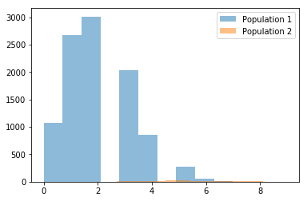

```
2.0022
1.269643713803207
5.24
1.6255460620972877
```

```python
pop1 = np.random.binomial(10, 0.2, 10000)
pop2 = np.random.binomial(10, 0.5, 100)

plt.hist(pop1, alpha=0.5,label='Population 1')
plt.hist(pop2, alpha=0.5, label='Population 2')
plt.legend(loc='upper right')
plt.show()

print(pop1.mean())
print(pop1.std())
print(pop2.mean())
print(pop2.std())
```

```
          Drill 1
```

Increased size sample from 100 to 1000

What I expect?

The mean and the standard deviation should increase when increasing the data. By increasing the number, the data is spreading even more and therefore the standard deviation should increase.

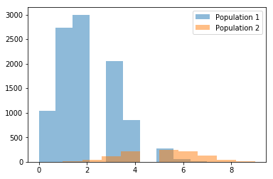

```
4.998
1.5420752251430538
```

```python
pop1 = np.random.binomial(10, 0.2, 10000)
pop2 = np.random.binomial(10, 0.5, 1000)

plt.hist(pop1, alpha=0.5,label='Population 1')
plt.hist(pop2, alpha=0.5, label='Population 2')
plt.legend(loc='upper right')
plt.show()

print(pop2.mean())
print(pop2.std())
```

Decrease size sample from 1000 to 20

What I expect?

Following the argument presented above, the mean and stardard deviation should decrease.

```python
pop2 = np.random.binomial(10, 0.5, 20)

print(pop2.mean())
print(pop2.std())
```

```
4.9
2.046948949045872
```

Drill 2

Change the probalility of pop1 to 0.3.

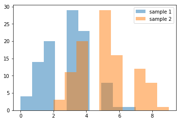

```python
pop1 = np.random.binomial(10, 0.3, 10000)
pop2 = np.random.binomial(10, 0.5, 10000)
subpop1 = np.random.choice(pop1, 100, replace=True)
subpop2 = np.random.choice(pop2, 100, replace=True)

plt.hist(subpop1, alpha=0.5, label='sample 1')
plt.hist(subpop2, alpha=0.5, label='sample 2')
plt.legend(loc='upper right')
plt.show()
```

```python
from scipy.stats import ttest_ind
print (ttest_ind(subpop2, subpop1, equal_var=False))
```

```
Ttest_indResult(statistic=11.082037452970086, pvalue=1.8546618460446309e-22)
```

Change the probability of pop1 to 0.4. What should happen?

The probability of pop2 is 0.5, changign the probability of pop3 to 04 makes the two samples a little similar. Therefore, we should expect a smaller T value since the stardard errors separaring the two means should be more narrowed. Therefore, the p value should probabibly be bigger indicating a greater probability of the null hypothesis being true.

```python
pop1 = np.random.binomial(10, 0.4, 10000)
pop2 = np.random.binomial(10, 0.5, 10000)
subpop1 = np.random.choice(pop1, 100, replace=True)
subpop2 = np.random.choice(pop2, 100, replace=True)

print (ttest_ind(subpop2, subpop1))
```

```
Ttest_indResult(statistic=4.777414848646971, pvalue=3.4520164017163983e-06)
```

Change the distribution from binomial to normal.

Does the sample mean still accurately represent the populations?

The sample mean being a good representation of the population would depend on the number of samples. The more samples the more it would resemble the population and display a normal distribution.

```
10.000835586960875
10.001872007788311
0.403952009758412
0.5058956045389621
```

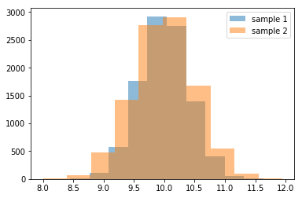

```python
pop1 = np.random.normal(10, 0.4, 10000)
pop2 = np.random.normal(10, 0.5, 10000)

print(pop1.mean())
print(pop2.mean())
print(pop1.std())
print(pop2.std())

plt.hist(pop1, alpha=0.5, label='sample 1')
plt.hist(pop2, alpha=0.5, label='sample 2')
plt.legend(loc='upper right')
plt.show()
```